# What makes a song a hit?

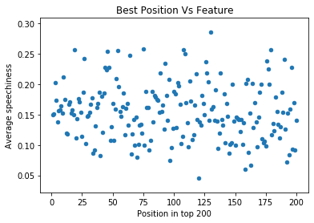

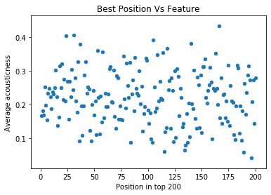

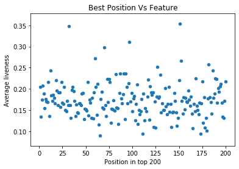

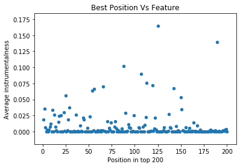

```python
probfeat=['speechiness', 'acousticness','liveness','instrumentalness']
for feat in probfeat:
    dfplot=pd.DataFrame(dfallnondup.groupby('Position')[feat].mean())
    dfplot.reset_index().plot(kind='scatter',x='Position',y=feat)
    plt.title('Best Position Vs Feature')
    plt.ylabel('Average '+ feat)
    plt.xlabel('Position in top 200')
```

We will use another approach of plotting for every distinct measure of the feature the average best position of songs with that feature

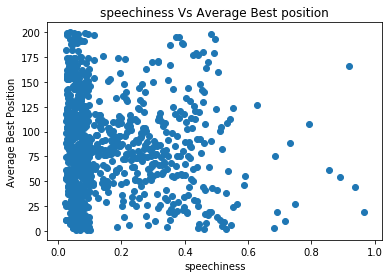

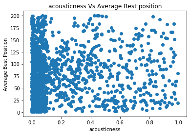

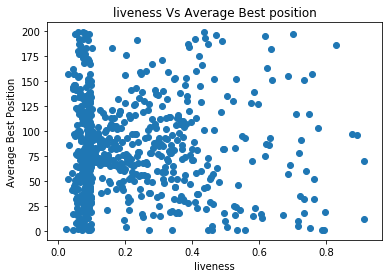

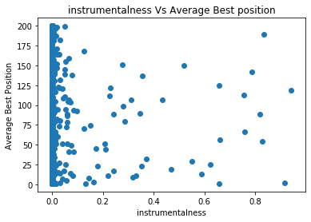

```python
probfeat=['speechiness', 'acousticness','liveness','instrumentalness']
for feat in probfeat:
    arrayf=dfallnondup[feat].unique()
    arrayf.sort()
    avgmc=[]
    for i in arrayf:
        datatemp=dfallnondup[dfallnondup[feat]==i]
        meantmp=datatemp['Position'].mean()
        avgmc.append(meantmp)
    plt.figure()
    plt.scatter(arrayf,avgmc)
    plt.title(feat+ ' Vs Average Best position')
    plt.xlabel(feat)
    plt.ylabel('Average Best Position')
```

Observations: These second set of graphs do not give us much information either. Most of the data is condensed in a specific region below 0.2. So although it appears as though certain percentage of liveness favor better position it may just be because there is less data point in that neighborhood.

The lack of a clear correlation between features and position in the charts suggests that making an accurate prediction may be difficult. In the 'Modelling' section several models are built to obtain a reliable result, but the metrics confirmed a certain difficulty to reach very good performance.

#### Discrete variables: key and mode

We will now investigate distribution among discrete variables 'key' and 'mode' and impact it has on song ranking

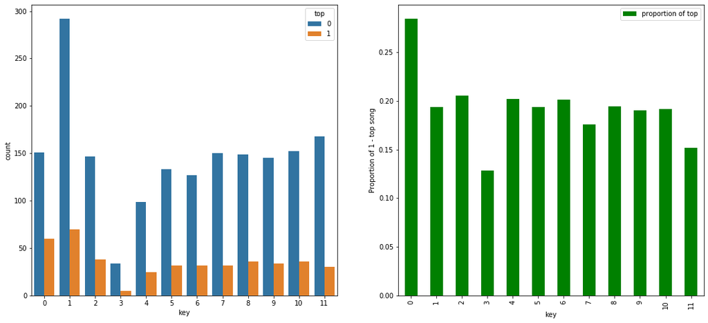

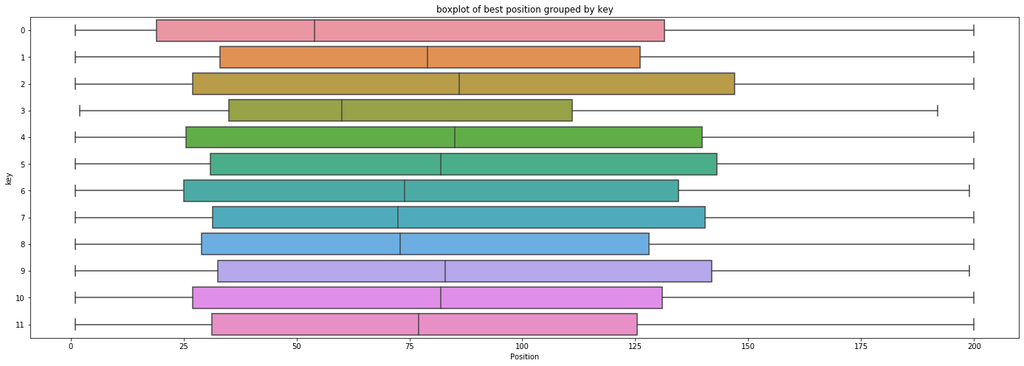

```python
### Discrete Variables Bar plot -key
fig, axs = plt.subplots(1, 2, figsize=(18, 8))
plt.axes(axs[0])
axs[0] = sns.countplot(x='key', hue='top', data=dfallnondup)
plt.axes(axs[1])
axs[1] = dfallnondup.groupby('key')['top'].mean().plot(kind='bar', color='g')
plt.legend(['proportion of top'])
plt.ylabel('Proportion of 1 - top song')


plt.figure(figsize=(24, 8))
sns.boxplot(x='Position', y='key', data=dfallnondup, orient='h')
plt.title('boxplot of best position grouped by key')
```

```python
dfallnondup[dfallnondup['key']==-1]
#this cell confirms there is no 'undetected' key which couldn't be identified by spotify- which is good news since it means no missing key values
```

|  | Position | Track Name | Artist | Streams | URL | danceability | energy | key | loudness | mode | ... | type | id | uri | track_href | analysis_url | duration_ms | time_signature | week | year | top |
| --- | --- | --- | --- | --- | --- | --- | --- | --- | --- | --- | --- | --- | --- | --- | --- | --- | --- | --- | --- | --- | --- |

0 rows × 26 columns

Observations: We see from proportion of top song bar graph and from the box plot above that using key=0 (corresponding to C) appears to favor song rankings and increases chances of a song being a top. On the other hand key=3 (corresponding to D sharp) appears to be the less likely to be a top. We also see from the first bar graph that in general there are relatively less songs in the category key=3 compared to the other ones.

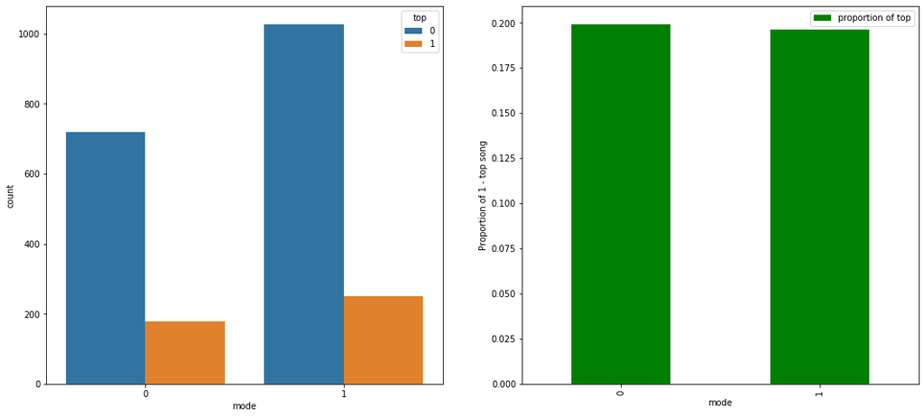

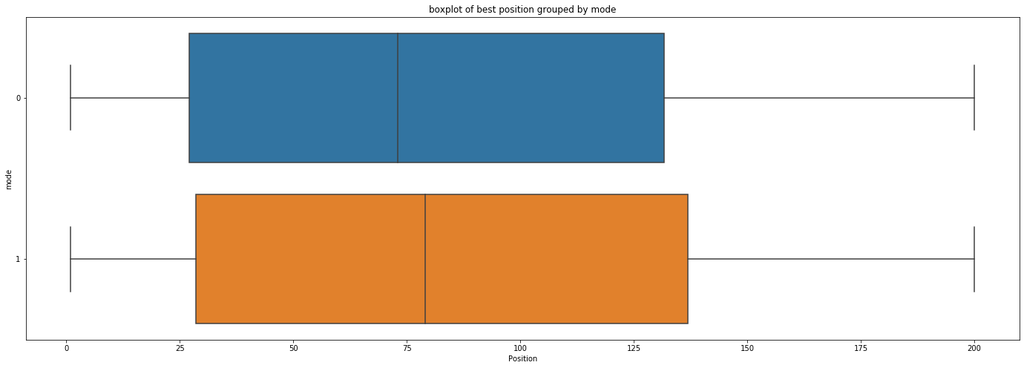

```python
### Discrete Variables Bar plot - mode
fig, axs = plt.subplots(1, 2, figsize=(18, 8))
plt.axes(axs[0])
axs[0] = sns.countplot(x='mode', hue='top', data=dfallnondup)
plt.axes(axs[1])
axs[1] = dfallnondup.groupby('mode')['top'].mean().plot(kind='bar', color='g')
plt.legend(['proportion of top'])
plt.ylabel('Proportion of 1 - top song')


plt.figure(figsize=(24, 8))
sns.boxplot(x='Position', y='mode', data=dfallnondup, orient='h')
plt.title('boxplot of best position grouped by mode')
```

Observations: Unlike they 'key' discrete variable. The mode 'major' (1) or 'minor' (0) doesn't seem to have significant impact on likelihood of being a top song. We do however notice there are more songs in the charts overall written in 'major'.

## Classification Model

```python
from sklearn.model_selection import train_test_split
from sklearn.linear_model import LogisticRegression, LogisticRegressionCV
from sklearn.model_selection import cross_val_score
from sklearn import svm
from sklearn.ensemble import RandomForestClassifier
from sklearn.metrics import confusion_matrix , classification_report
from sklearn.preprocessing import MinMaxScaler, StandardScaler
from sklearn.metrics import roc_curve, precision_recall_curve, auc, make_scorer, recall_score, accuracy_score, precision_score, confusion_matrix,average_precision_score, f1_score
```

## 1st iteration: a successful song is defined as one entering the top 10% of the chart

This iteration used the obsolete KPI 1, it is included for completeness. The main model that we focus on for this project is the second iteration with KPI2.

### Random forest

using all data dfall without oversamplig

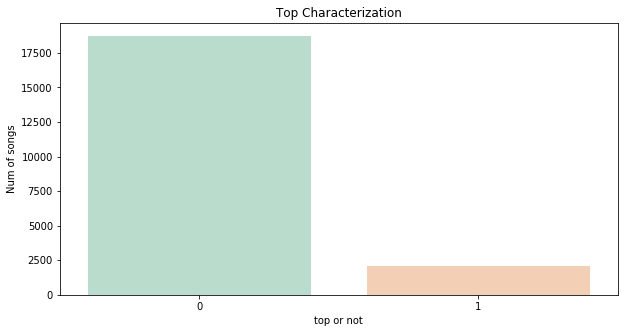

```python
plt.figure(figsize=(10, 5))
ax = sns.countplot(data=dfall, x='top',palette="Pastel2")
ax.set(xlabel='top or not', ylabel='Num of songs')
plt.title("Top Characterization")
plt.show()
```

```
Accuracy Score: 0.9120192307692307
Recall Score: 0.2668269230769231
Precision Score: 0.6453488372093024
F1 Score: 0.37755102040816324
```

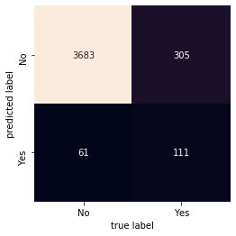

```python
features=['danceability','energy','key','loudness','mode' ,'speechiness','acousticness','instrumentalness','liveness','valence','tempo','time_signature','duration_ms']
X=dfall[features]
y=dfall['top']
X_train, X_test, y_train, y_test = train_test_split(X, y,stratify=y, test_size=0.2)

clf= RandomForestClassifier()
clf.fit(X_train,y_train)
y_pred= clf.predict(X_test)
mat = confusion_matrix(y_test, y_pred)
s1=sns.heatmap(mat.T, square=True, annot=True, fmt='d', cbar=False,
          xticklabels=['No','Yes'],
          yticklabels=['No','Yes'] )
plt.xlabel('true label')
plt.ylabel('predicted label')
bottom, top = s1.get_ylim()
s1.set_ylim(bottom + 0.5, top - 0.5)

print("Accuracy Score:",accuracy_score(y_test,y_pred))
print("Recall Score:",recall_score(y_test,y_pred,labels=[1,0]))
print("Precision Score:",precision_score(y_test,y_pred,labels=[1,0]))
print("F1 Score:",f1_score(y_test,y_pred,labels=[1,0]))
```

Since the database is strongly unbalanced, the model is repeated with oversampling

```
df1count  1664
df0count  14976
df1_over  14976
```

```
Accuracy Score: 0.7576923076923077
Recall Score: 0.7932692307692307
Precision Score: 0.26357827476038337
F1 Score: 0.39568345323741005
```

```
(2.0, 0.0)
```

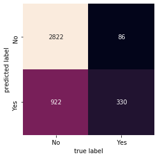

```python
X_train, X_test, y_train, y_test = train_test_split(dfall, dfall["top"], stratify=dfall["top"],test_size=0.2)
features=['danceability','energy','key','loudness','mode' ,'speechiness','acousticness','instrumentalness','liveness','valence','tempo','time_signature','duration_ms']
# Divide by class
df0 = X_train[X_train['top'] == 0]
df1 = X_train[X_train['top'] == 1]
df1count=df1.shape[0]
df0count=df0.shape[0]
print('df1count ',df1count)
print('df0count ',df0count)
df1_over = df1.sample(df0count, replace=True)
print('df1_over ', df1_over.shape[0])
X_trainb=pd.concat([df1_over, df0], ignore_index=True) #new training Xb balanced
y_train=X_trainb['top']
X_trainb=X_trainb[features]
X_test=X_test[features]
#retry random forest classifier
clf = RandomForestClassifier()
clf.fit(X_trainb, y_train)

y_pred=clf.predict(X_test)

print("Accuracy Score:",accuracy_score(y_test,y_pred))
print("Recall Score:",recall_score(y_test,y_pred,labels=[1,0]))
print("Precision Score:",precision_score(y_test,y_pred,labels=[1,0]))
print("F1 Score:",f1_score(y_test,y_pred,labels=[1,0]))

mat = confusion_matrix(y_test, y_pred)
s1=sns.heatmap(mat.T, square=True, annot=True, fmt='d', cbar=False,
          xticklabels=['No','Yes'],
          yticklabels=['No','Yes'] )
plt.xlabel('true label')
plt.ylabel('predicted label')
bottom, top = s1.get_ylim()
s1.set_ylim(bottom + 0.5, top - 0.5)
```

Applying oversampling in the database improves the recall score of the model, which is the most interesting one since the goal is to predict which songs will be successful.

### SVM

using dfall without oversampling

```
Accuracy Score: 0.9033653846153846
Recall Score: 0.055288461538461536
Precision Score: 0.71875
F1 Score: 0.10267857142857142
```

```
(2.0, 0.0)
```

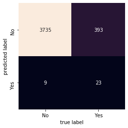

```python
features=['danceability','energy','key','loudness','mode' ,'speechiness','acousticness','instrumentalness','liveness','valence','tempo','time_signature','duration_ms']
X=dfall[features]
scaler =StandardScaler()
X= pd.DataFrame(scaler.fit_transform(X),columns=X.columns)
y=dfall['top']
X_train, X_test, y_train, y_test = train_test_split(X, y,stratify=y, test_size=0.2)

clf = svm.SVC()
clf.fit(X_train, y_train)

y_pred=clf.predict(X_test)

print("Accuracy Score:",accuracy_score(y_test,y_pred))
print("Recall Score:",recall_score(y_test,y_pred,labels=[1,0]))
print("Precision Score:",precision_score(y_test,y_pred,labels=[1,0]))
print("F1 Score:",f1_score(y_test,y_pred,labels=[1,0]))

mat = confusion_matrix(y_test, y_pred)
s1=sns.heatmap(mat.T, square=True, annot=True, fmt='d', cbar=False,
          xticklabels=['No','Yes'],
          yticklabels=['No','Yes'] )
plt.xlabel('true label')
plt.ylabel('predicted label')
bottom, top = s1.get_ylim()
s1.set_ylim(bottom + 0.5, top - 0.5)
```

svm with oversampling

```
df1count  1664
df0count  14976
df1_over  14976
```

```
Accuracy Score: 0.7151442307692307
Recall Score: 0.7860576923076923
Precision Score: 0.2297962052002811
F1 Score: 0.3556280587275693
```

```
(2.0, 0.0)
```

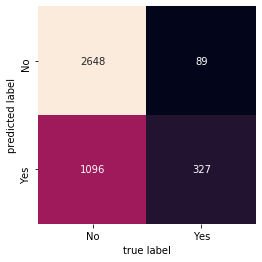

```python
features=['danceability','energy','key','loudness','mode' ,'speechiness','acousticness','instrumentalness','liveness','valence','tempo','time_signature','duration_ms']
df_scaled = dfall.copy()
scaler =StandardScaler()
df_scaled[features] = scaler.fit_transform(df_scaled[features])

X_train, X_test, y_train, y_test = train_test_split(df_scaled, df_scaled["top"], stratify=df_scaled["top"],test_size=0.2)

# Divide by class
df0 = X_train[X_train['top'] == 0]
df1 = X_train[X_train['top'] == 1]
df1count=df1.shape[0]
df0count=df0.shape[0]
print('df1count ',df1count)
print('df0count ',df0count)
df1_over = df1.sample(df0count, replace=True)
print('df1_over ', df1_over.shape[0])
X_trainb=pd.concat([df1_over, df0], ignore_index=True) #new training Xb balanced
y_train=X_trainb['top']
X_trainb=X_trainb[features]
X_test=X_test[features]


#retry svm
clf = svm.SVC()
clf.fit(X_trainb, y_train)

y_pred=clf.predict(X_test)

print("Accuracy Score:",accuracy_score(y_test,y_pred))
print("Recall Score:",recall_score(y_test,y_pred,labels=[1,0]))
print("Precision Score:",precision_score(y_test,y_pred,labels=[1,0]))
print("F1 Score:",f1_score(y_test,y_pred,labels=[1,0]))

mat = confusion_matrix(y_test, y_pred)
s1=sns.heatmap(mat.T, square=True, annot=True, fmt='d', cbar=False,
          xticklabels=['No','Yes'],
          yticklabels=['No','Yes'] )
plt.xlabel('true label')
plt.ylabel('predicted label')
bottom, top = s1.get_ylim()
s1.set_ylim(bottom + 0.5, top - 0.5)
```

```
df1count  1664
df0count  14976
df1_over  14976
Accuracy Score: 0.5439903846153846
Recall Score: 0.6322115384615384
Precision Score: 0.1310413552566019
F1 Score: 0.21708625670656212
```

```
(2.0, 0.0)
```

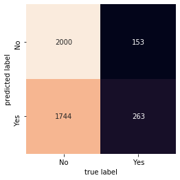

```python
features=['danceability','energy','key','loudness','mode' ,'speechiness','acousticness','instrumentalness','liveness','valence','tempo','time_signature','duration_ms']
df_scaled = dfall.copy()
scaler =StandardScaler()
df_scaled[features] = scaler.fit_transform(df_scaled[features])

X_train, X_test, y_train, y_test = train_test_split(df_scaled, df_scaled["top"], stratify=df_scaled["top"],test_size=0.2)

# Divide by class
df0 = X_train[X_train['top'] == 0]
df1 = X_train[X_train['top'] == 1]
df1count=df1.shape[0]
df0count=df0.shape[0]
print('df1count ',df1count)
print('df0count ',df0count)
df1_over = df1.sample(df0count, replace=True)
print('df1_over ', df1_over.shape[0])
X_trainb=pd.concat([df1_over, df0], ignore_index=True) #new training Xb balanced
y_train=X_trainb['top']
X_trainb=X_trainb[features]
X_test=X_test[features]


#retry svm
clf = svm.SVC(kernel='linear')
clf.fit(X_trainb, y_train)

y_pred=clf.predict(X_test)

print("Accuracy Score:",accuracy_score(y_test,y_pred))
print("Recall Score:",recall_score(y_test,y_pred,labels=[1,0]))
print("Precision Score:",precision_score(y_test,y_pred,labels=[1,0]))
print("F1 Score:",f1_score(y_test,y_pred,labels=[1,0]))

mat = confusion_matrix(y_test, y_pred)
s1=sns.heatmap(mat.T, square=True, annot=True, fmt='d', cbar=False,
          xticklabels=['No','Yes'],
          yticklabels=['No','Yes'] )
plt.xlabel('true label')
plt.ylabel('predicted label')
bottom, top = s1.get_ylim()
s1.set_ylim(bottom + 0.5, top - 0.5)
```

### Logistic Regression

without oversampling

```
Accuracy Score: 0.9
Recall Score: 0.0
Precision Score: 0.0
F1 Score: 0.0
```

```
(2.0, 0.0)
```

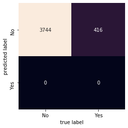

```python
features=['danceability','energy','key','loudness','mode' ,'speechiness','acousticness','instrumentalness','liveness','valence','tempo','time_signature']
X=dfall[features]
y=dfall['top']
X_train, X_test, y_train, y_test = train_test_split(X, y,stratify=y, test_size=0.2)
logReg = LogisticRegression(max_iter=10000)
logReg.fit(X_train, y_train)
y_pred=predictions = logReg.predict(X_test)

print("Accuracy Score:",accuracy_score(y_test,y_pred))
print("Recall Score:",recall_score(y_test,y_pred,labels=[1,0]))
print("Precision Score:",precision_score(y_test,y_pred,labels=[1,0]))
print("F1 Score:",f1_score(y_test,y_pred,labels=[1,0]))

mat = confusion_matrix(y_test, y_pred)
s1=sns.heatmap(mat.T, square=True, annot=True, fmt='d', cbar=False,
          xticklabels=['No','Yes'],
          yticklabels=['No','Yes'] )
plt.xlabel('true label')
plt.ylabel('predicted label')
bottom, top = s1.get_ylim()
s1.set_ylim(bottom + 0.5, top - 0.5)
```

with oversampling

```
df1count  1664
df0count  14976
df1_over  14976
Accuracy Score: 0.5644230769230769
Recall Score: 0.5817307692307693
Precision Score: 0.12872340425531914
F1 Score: 0.210801393728223
```

```
(2.0, 0.0)
```

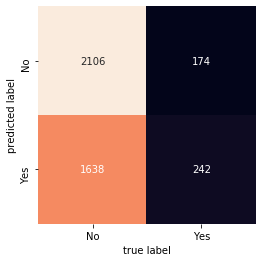

```python
X_train, X_test, y_train, y_test = train_test_split(dfall, dfall["top"], stratify=dfall["top"],test_size=0.2)
features=['danceability','energy','key','loudness','mode' ,'speechiness','acousticness','instrumentalness','liveness','valence','tempo','time_signature']
# Divide by class
df0 = X_train[X_train['top'] == 0]
df1 = X_train[X_train['top'] == 1]
df1count=df1.shape[0]
df0count=df0.shape[0]
print('df1count ',df1count)
print('df0count ',df0count)
df1_over = df1.sample(df0count, replace=True)
print('df1_over ', df1_over.shape[0])
X_trainb=pd.concat([df1_over, df0], ignore_index=True) #new training Xb balanced
y_train=X_trainb['top']
X_trainb=X_trainb[features]
X_test=X_test[features]
#retry logistic
logReg = LogisticRegression(max_iter=10000)
logReg.fit(X_trainb, y_train)
y_pred=predictions = logReg.predict(X_test)

print("Accuracy Score:",accuracy_score(y_test,y_pred))
print("Recall Score:",recall_score(y_test,y_pred,labels=[1,0]))
print("Precision Score:",precision_score(y_test,y_pred,labels=[1,0]))
print("F1 Score:",f1_score(y_test,y_pred,labels=[1,0]))

mat = confusion_matrix(y_test, y_pred)
s1=sns.heatmap(mat.T, square=True, annot=True, fmt='d', cbar=False,
          xticklabels=['No','Yes'],
          yticklabels=['No','Yes'] )
plt.xlabel('true label')
plt.ylabel('predicted label')
bottom, top = s1.get_ylim()
s1.set_ylim(bottom + 0.5, top - 0.5)
```

After applying three different models, it can be observed that none of them has very good performance. Reasoning on the possible causes of these results, the team realized that the definition of success was not appropriate; therefore, a new one is defined and the analysis is repeated.

## 2nd iteration: Looking at songs as individual distinct songs

Using a second success definition (KPI 2), a song is ranked a hit if reached top at least once in 2018 or 2019

After realizing that the same song appeared multiple times in different positions in the database, the available data have been updated keeping just one appearance per song in the highest position it reached.

```python
#number of distinct track name in 2019 200 weekly charts
dfall['Track Name'].unique().size
```

```
2177
```

```python
dfalltop=dfall[dfall['top']==1]
dfalltop['Track Name'].unique().size
```

```
430
```

Sort in ascending the postion, so ony keep lower (so best on top 200) of each unique song and drop duplicates

```python
dfallnondup=dfall.sort_values('Position', ascending=True).drop_duplicates('Track Name')
dfallnondup.index = np.arange(len(dfallnondup))
dfallnondup.head()
```

|  | Position | Track Name | Artist | Streams | URL | danceability | energy | key | loudness | mode | ... | type | id | uri | track_href | analysis_url | duration_ms | time_signature | week | year | top |
| --- | --- | --- | --- | --- | --- | --- | --- | --- | --- | --- | --- | --- | --- | --- | --- | --- | --- | --- | --- | --- | --- |
| 0 | 1 | rockstar | Post Malone | 9855305 | https://open.spotify.com/track/7wGoVu4Dady5GV0... | 0.577 | 0.522 | 5 | -6.594 | 0 | ... | audio_features | 7wGoVu4Dady5GV0Sv4UIsx | spotify:track:7wGoVu4Dady5GV0Sv4UIsx | https://api.spotify.com/v1/tracks/7wGoVu4Dady5... | https://api.spotify.com/v1/audio-analysis/7wGo... | 218320 | 4 | 1 | 2018 | 1 |
| 1 | 1 | Nice For What | Drake | 19830250 | https://open.spotify.com/track/1cTZMwcBJT0Ka3U... | 0.567 | 0.913 | 8 | -6.471 | 1 | ... | audio_features | 1cTZMwcBJT0Ka3UJPXOeeN | spotify:track:1cTZMwcBJT0Ka3UJPXOeeN | https://api.spotify.com/v1/tracks/1cTZMwcBJT0K... | https://api.spotify.com/v1/audio-analysis/1cTZ... | 210926 | 4 | 15 | 2018 | 1 |
| 2 | 1 | Circles | Post Malone | 12719540 | https://open.spotify.com/track/21jGcNKet2qwijl... | 0.695 | 0.762 | 0 | -3.497 | 1 | ... | audio_features | 21jGcNKet2qwijlDFuPiPb | spotify:track:21jGcNKet2qwijlDFuPiPb | https://api.spotify.com/v1/tracks/21jGcNKet2qw... | https://api.spotify.com/v1/audio-analysis/21jG... | 215280 | 4 | 37 | 2019 | 1 |
| 3 | 1 | Better Now | Post Malone | 21229827 | https://open.spotify.com/track/7dt6x5M1jzdTEt8... | 0.680 | 0.578 | 10 | -5.804 | 1 | ... | audio_features | 7dt6x5M1jzdTEt8oCbisTK | spotify:track:7dt6x5M1jzdTEt8oCbisTK | https://api.spotify.com/v1/tracks/7dt6x5M1jzdT... | https://api.spotify.com/v1/audio-analysis/7dt6... | 231267 | 4 | 17 | 2018 | 1 |
| 4 | 1 | Lover | Taylor Swift | 12784772 | https://open.spotify.com/track/1dGr1c8CrMLDpV6... | 0.359 | 0.543 | 7 | -7.582 | 1 | ... | audio_features | 1dGr1c8CrMLDpV6mPbImSI | spotify:track:1dGr1c8CrMLDpV6mPbImSI | https://api.spotify.com/v1/tracks/1dGr1c8CrMLD... | https://api.spotify.com/v1/audio-analysis/1dGr... | 221307 | 4 | 34 | 2019 | 1 |

5 rows × 26 columns

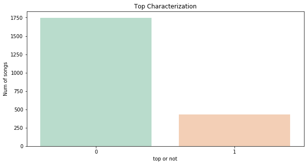

```python
## visualizing distribution of top and not top unique songs
plt.figure(figsize=(10, 5))
ax = sns.countplot(data=dfallnondup, x='top',palette="Pastel2")
ax.set(xlabel='top or not', ylabel='Num of songs')
plt.title("Top Characterization")
plt.show()
```

#### Random Forest without oversampling

```
Accuracy Score: 0.7844036697247706
Recall Score: 0.08139534883720931
Precision Score: 0.3181818181818182
F1 Score: 0.12962962962962965
```

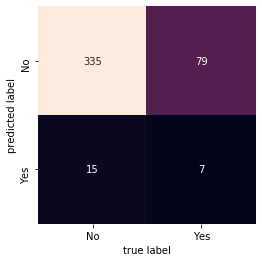

```python
features=['danceability','energy','key','loudness','mode' ,'speechiness','acousticness','instrumentalness','liveness','valence','tempo','time_signature','duration_ms']
X=dfallnondup[features]
y=dfallnondup['top']
X_train, X_test, y_train, y_test = train_test_split(X, y,stratify=y, test_size=0.2)

clf= RandomForestClassifier()
clf.fit(X_train,y_train)
y_pred= clf.predict(X_test)
mat = confusion_matrix(y_test, y_pred)
s1=sns.heatmap(mat.T, square=True, annot=True, fmt='d', cbar=False,
          xticklabels=['No','Yes'],
          yticklabels=['No','Yes'] )
plt.xlabel('true label')
plt.ylabel('predicted label')
bottom, top = s1.get_ylim()
s1.set_ylim(bottom + 0.5, top - 0.5)

print("Accuracy Score:",accuracy_score(y_test,y_pred))
print("Recall Score:",recall_score(y_test,y_pred,labels=[1,0]))
print("Precision Score:",precision_score(y_test,y_pred,labels=[1,0]))
print("F1 Score:",f1_score(y_test,y_pred,labels=[1,0]))
```

#### Random Forest with oversampling

```
df1count  344
df0count  1397
df1_over  1397
Accuracy Score: 0.768348623853211
Recall Score: 0.09302325581395349
Precision Score: 0.25806451612903225
F1 Score: 0.13675213675213674
```

```
(2.0, 0.0)
```

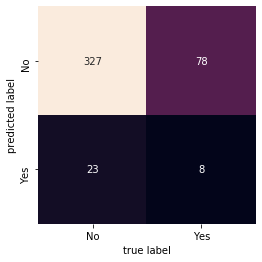

```python
X_train, X_test, y_train, y_test = train_test_split(dfallnondup, dfallnondup["top"], stratify=dfallnondup["top"],test_size=0.2)
features=['danceability','energy','key','loudness','mode' ,'speechiness','acousticness','instrumentalness','liveness','valence','tempo','time_signature','duration_ms']
# Divide by class
df0 = X_train[X_train['top'] == 0]
df1 = X_train[X_train['top'] == 1]
df1count=df1.shape[0]
df0count=df0.shape[0]
print('df1count ',df1count)
print('df0count ',df0count)
df1_over = df1.sample(df0count, replace=True)
print('df1_over ', df1_over.shape[0])
X_trainb=pd.concat([df1_over, df0], ignore_index=True) #new training Xb balanced
y_train=X_trainb['top']
X_trainb=X_trainb[features]
X_test=X_test[features]
#retry random forest classifier
clf = RandomForestClassifier()
clf.fit(X_trainb, y_train)

y_pred=clf.predict(X_test)

print("Accuracy Score:",accuracy_score(y_test,y_pred))
print("Recall Score:",recall_score(y_test,y_pred,labels=[1,0]))
print("Precision Score:",precision_score(y_test,y_pred,labels=[1,0]))
print("F1 Score:",f1_score(y_test,y_pred,labels=[1,0]))

mat = confusion_matrix(y_test, y_pred)
s1=sns.heatmap(mat.T, square=True, annot=True, fmt='d', cbar=False,
          xticklabels=['No','Yes'],
          yticklabels=['No','Yes'] )
plt.xlabel('true label')
plt.ylabel('predicted label')
bottom, top = s1.get_ylim()
s1.set_ylim(bottom + 0.5, top - 0.5)
```

#### Random Forest with Cross-Validation

hyperparameters to tune: min_samples_leaf and max depth

```python
leaf=[1,2,3,4,5]
depths = list(np.linspace(1, 30, 30, endpoint=True))
depths.append(None)

X_train, X_test, y_train, y_test = train_test_split(dfallnondup, dfallnondup["top"], stratify=dfallnondup["top"],test_size=0.2)
features=['danceability','energy','key','loudness','mode' ,'speechiness','acousticness','instrumentalness','liveness','valence','tempo','time_signature','duration_ms']
# Divide by class
df0 = X_train[X_train['top'] == 0]
df1 = X_train[X_train['top'] == 1]
df1count=df1.shape[0]
df0count=df0.shape[0]
print('df1count ',df1count)
print('df0count ',df0count)
df1_over = df1.sample(df0count, replace=True)
print('df1_over ', df1_over.shape[0])
X_trainb=pd.concat([df1_over, df0], ignore_index=True) #new training Xb balanced
y_train=X_trainb['top']
X_trainb=X_trainb[features]
X_test=X_test[features]
#retry random forest classifier

scorerf= []
for l in leaf:
    ltmp=[]
    for d in depths:
        clf = RandomForestClassifier(max_depth=d, min_samples_leaf=l)
        ltmp.append(np.mean(cross_val_score(clf, X_trainb, y_train, cv=5, scoring='f1')))
    scorerf.append(ltmp)
```

```
df1count  344
df0count  1397
df1_over  1397
```

[output not shown]

[output cut: 1495 more lines]

[output not shown]

```python
scorerf=np.array(scorerf)
maxindex = scorerf.argmax()
from numpy import unravel_index
ind=unravel_index(scorerf.argmax(), scorerf.shape)
print('scorerf: ', np.amax(scorerf))
print('index: ', ind)
```

```
scorerf:  0.9400758174327933
index:  (0, 29)
```

The first index relates to the min_leaf parameter and the second the max_depth parameter. As seen in the cell below, it is bes to use min_leaf of 1 and max_depth of 30.

```python
leafvar = leaf[ind[0]]
print('leaf', leafvar)
depthvar = depths[ind[1]]
print('depth', depthvar)
```

```
leaf 1
depth 30.0
```

Here we are executing the final random forest with oversampling and tuned parameters

```
Accuracy Score: 0.786697247706422
Recall Score: 0.05813953488372093
Precision Score: 0.29411764705882354
F1 Score: 0.0970873786407767
```

```
(2.0, 0.0)
```

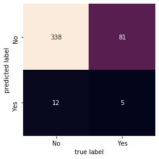

```python
clf = RandomForestClassifier(min_samples_leaf=leafvar, max_depth=depthvar)
clf.fit(X_trainb, y_train)

y_pred=clf.predict(X_test)

print("Accuracy Score:",accuracy_score(y_test,y_pred))
print("Recall Score:",recall_score(y_test,y_pred,labels=[1,0]))
print("Precision Score:",precision_score(y_test,y_pred,labels=[1,0]))
print("F1 Score:",f1_score(y_test,y_pred,labels=[1,0]))

mat = confusion_matrix(y_test, y_pred)
s1=sns.heatmap(mat.T, square=True, annot=True, fmt='d', cbar=False,
          xticklabels=['No','Yes'],
          yticklabels=['No','Yes'] )
plt.xlabel('true label')
plt.ylabel('predicted label')
bottom, top = s1.get_ylim()
s1.set_ylim(bottom + 0.5, top - 0.5)
```

A cross validation is used to avoid overfitting in the model, and to tune the parameters of the model. However, it is important to note that the metrics obtained are not the best ones in absolute terms, but the best ones when averaging the results of different database split selection and not selecting a single specific one.

### SVM

without oversampling

```
Accuracy Score: 0.8027522935779816
Recall Score: 0.0
Precision Score: 0.0
F1 Score: 0.0
```

```
(2.0, 0.0)
```

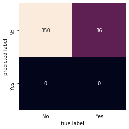

```python
features=['danceability','energy','key','loudness','mode' ,'speechiness','acousticness','instrumentalness','liveness','valence','tempo','time_signature','duration_ms']
X=dfallnondup[features]
scaler =StandardScaler()
X= pd.DataFrame(scaler.fit_transform(X),columns=X.columns)
y=dfallnondup['top']
X_train, X_test, y_train, y_test = train_test_split(X, y,stratify=y, test_size=0.2)

clf = svm.SVC()
clf.fit(X_train, y_train)

y_pred=clf.predict(X_test)

print("Accuracy Score:",accuracy_score(y_test,y_pred))
print("Recall Score:",recall_score(y_test,y_pred,labels=[1,0]))
print("Precision Score:",precision_score(y_test,y_pred,labels=[1,0]))
print("F1 Score:",f1_score(y_test,y_pred,labels=[1,0]))

mat = confusion_matrix(y_test, y_pred)
s1=sns.heatmap(mat.T, square=True, annot=True, fmt='d', cbar=False,
          xticklabels=['No','Yes'],
          yticklabels=['No','Yes'] )
plt.xlabel('true label')
plt.ylabel('predicted label')
bottom, top = s1.get_ylim()
s1.set_ylim(bottom + 0.5, top - 0.5)
```

with oversampling

```
df1count  344
df0count  1397
df1_over  1397
Accuracy Score: 0.5848623853211009
Recall Score: 0.3372093023255814
Precision Score: 0.1895424836601307
F1 Score: 0.24267782426778248
```

```
(2.0, 0.0)
```

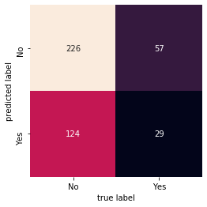

```python
features=['danceability','energy','key','loudness','mode' ,'speechiness','acousticness','instrumentalness','liveness','valence','tempo','time_signature','duration_ms']
df_scaled = dfallnondup.copy()
scaler =StandardScaler()
df_scaled[features] = scaler.fit_transform(df_scaled[features])

X_train, X_test, y_train, y_test = train_test_split(df_scaled, df_scaled["top"], stratify=df_scaled["top"],test_size=0.2)

# Divide by class
df0 = X_train[X_train['top'] == 0]
df1 = X_train[X_train['top'] == 1]
df1count=df1.shape[0]
df0count=df0.shape[0]
print('df1count ',df1count)
print('df0count ',df0count)
df1_over = df1.sample(df0count, replace=True)
print('df1_over ', df1_over.shape[0])
X_trainb=pd.concat([df1_over, df0], ignore_index=True) #new training Xb balanced
y_train=X_trainb['top']
X_trainb=X_trainb[features]
X_test=X_test[features]


#retry svm
clf = svm.SVC()
clf.fit(X_trainb, y_train)

y_pred=clf.predict(X_test)

print("Accuracy Score:",accuracy_score(y_test,y_pred))
print("Recall Score:",recall_score(y_test,y_pred,labels=[1,0]))
print("Precision Score:",precision_score(y_test,y_pred,labels=[1,0]))
print("F1 Score:",f1_score(y_test,y_pred,labels=[1,0]))

mat = confusion_matrix(y_test, y_pred)
s1=sns.heatmap(mat.T, square=True, annot=True, fmt='d', cbar=False,
          xticklabels=['No','Yes'],
          yticklabels=['No','Yes'] )
plt.xlabel('true label')
plt.ylabel('predicted label')
bottom, top = s1.get_ylim()
s1.set_ylim(bottom + 0.5, top - 0.5)
```

Notes: evidently balancing out the dataset was necessary

#### SVM cross-validation hyperparameter tuning

Let's see of we can tune our svm model by changing kernels and paramers such as C or degree

```python
features=['danceability','energy','key','loudness','mode' ,'speechiness','acousticness','instrumentalness','liveness','valence','tempo','time_signature','duration_ms']
df_scaled = dfallnondup.copy()
scaler =StandardScaler()
df_scaled[features] = scaler.fit_transform(df_scaled[features])

X_train, X_test, y_train, y_test = train_test_split(df_scaled, df_scaled["top"], stratify=df_scaled["top"],test_size=0.2)

# Divide by class
df0 = X_train[X_train['top'] == 0]
df1 = X_train[X_train['top'] == 1]
df1count=df1.shape[0]
df0count=df0.shape[0]
print('df1count ',df1count)
print('df0count ',df0count)
df1_over = df1.sample(df0count, replace=True)
print('df1_over ', df1_over.shape[0])
X_trainb=pd.concat([df1_over, df0], ignore_index=True) #new training Xb balanced
y_train=X_trainb['top']
X_trainb=X_trainb[features]
X_test=X_test[features]

scores=[]
scoresrbf=[]
scoresig=[]
scorespoly=[]

#retry svm cross validation
for i in [1,10,10^2,10^3,10^4,10^5]:
    clf = svm.SVC(kernel='linear', C=i)
    scores.append(np.mean(cross_val_score(clf, X_trainb, y_train, cv=5, scoring='f1')))
    clfrbf=svm.SVC(kernel='rbf', C=i)
    scoresrbf.append(np.mean(cross_val_score(clfrbf, X_trainb, y_train, cv=5, scoring='f1')))
    clfsig = svm.SVC(kernel='sigmoid', C=i)
    scoresig.append(np.mean(cross_val_score(clfsig, X_trainb, y_train, cv=5, scoring='f1')))
for d in [1,2,3,4,5,6]:
    clfpoly=svm.SVC(kernel='poly', degree=d)
    scorespoly.append(np.mean(cross_val_score(clfpoly, X_trainb, y_train, cv=5, scoring='f1')))


"""
print("Accuracy Score:",accuracy_score(y_test,y_pred))
print("Recall Score:",recall_score(y_test,y_pred,labels=[1,0]))
print("Precision Score:",precision_score(y_test,y_pred,labels=[1,0]))

mat = confusion_matrix(y_test, y_pred)
s1=sns.heatmap(mat.T, square=True, annot=True, fmt='d', cbar=False,
          xticklabels=['No','Yes'],
          yticklabels=['No','Yes'] )
plt.xlabel('true label')
plt.ylabel('predicted label')
bottom, top = s1.get_ylim()
s1.set_ylim(bottom + 0.5, top - 0.5)
"""
```

```
df1count  344
df0count  1397
df1_over  1397
```

[output not shown]

[output cut: 154 more lines]

```
'\nprint("Accuracy Score:",accuracy_score(y_test,y_pred))\nprint("Recall Score:",recall_score(y_test,y_pred,labels=[1,0]))\nprint("Precision Score:",precision_score(y_test,y_pred,labels=[1,0]))\n\nmat = confusion_matrix(y_test, y_pred)\ns1=sns.heatmap(mat.T, square=True, annot=True, fmt=\'d\', cbar=…
```

```python
print('score: ',scores)
print('scorerbf: ',scoresrbf)
print('scorepoly: ',scorespoly)
print('scoresig: ', scoresig )
```

```
score:  [0.5334086011915877, 0.5337634948010386, 0.5345111583524405, 0.5339497106293839, 0.5345111583524405, 0.5332123627460066]
scorerbf:  [0.6855570838288101, 0.7843777497486023, 0.7739821276427749, 0.7790660125048368, 0.7929531868639711, 0.7911635999369813]
scorepoly:  [0.5339325140406339, 0.6284292610038127, 0.6228099680192841, 0.6556106588667274, 0.5738203339374854, 0.545910551976156]
scoresig:  [0.44530768764328654, 0.47849852495764544, 0.48234096156712675, 0.47799004075110385, 0.47554235567686404, 0.47369210473351375]
```

```
Accuracy Score: 0.6055045871559633
Recall Score: 0.4069767441860465
Precision Score: 0.22435897435897437
f1score:  0.2892561983471074
```

```
(2.0, 0.0)
```

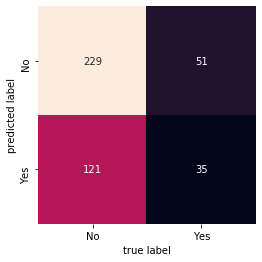

```python
#retry svm
i=10^5
clf=svm.SVC(kernel='rbf', C=i)
clf.fit(X_trainb, y_train)

y_pred=clf.predict(X_test)

print("Accuracy Score:",accuracy_score(y_test,y_pred))
print("Recall Score:",recall_score(y_test,y_pred,labels=[1,0]))
print("Precision Score:",precision_score(y_test,y_pred,labels=[1,0]))
print("f1score: ", 2/(1/recall_score(y_test,y_pred,labels=[1,0])+1/precision_score(y_test,y_pred,labels=[1,0])))

mat = confusion_matrix(y_test, y_pred)
s1=sns.heatmap(mat.T, square=True, annot=True, fmt='d', cbar=False,
          xticklabels=['No','Yes'],
          yticklabels=['No','Yes'] )
plt.xlabel('true label')
plt.ylabel('predicted label')
bottom, top = s1.get_ylim()
s1.set_ylim(bottom + 0.5, top - 0.5)
```

### Logistic regression

without oversampling

```
Accuracy Score: 0.8027522935779816
Recall Score: 0.0
Precision Score: 0.0
F1 Score: 0.0
```

```
(2.0, 0.0)
```

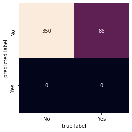

```python
features=['danceability','energy','key','loudness','mode' ,'speechiness','acousticness','instrumentalness','liveness','valence','tempo','time_signature']
X=dfallnondup[features]
y=dfallnondup['top']
X_train, X_test, y_train, y_test = train_test_split(X, y,stratify=y, test_size=0.2)
logReg = LogisticRegression(max_iter=10000)
logReg.fit(X_train, y_train)
y_pred=predictions = logReg.predict(X_test)

print("Accuracy Score:",accuracy_score(y_test,y_pred))
print("Recall Score:",recall_score(y_test,y_pred,labels=[1,0]))
print("Precision Score:",precision_score(y_test,y_pred,labels=[1,0]))
print("F1 Score:",f1_score(y_test,y_pred,labels=[1,0]))

mat = confusion_matrix(y_test, y_pred)
s1=sns.heatmap(mat.T, square=True, annot=True, fmt='d', cbar=False,
          xticklabels=['No','Yes'],
          yticklabels=['No','Yes'] )
plt.xlabel('true label')
plt.ylabel('predicted label')
bottom, top = s1.get_ylim()
s1.set_ylim(bottom + 0.5, top - 0.5)
```

with oversampling

```
df1count  344
df0count  1397
df1_over  1397
Accuracy Score: 0.5779816513761468
Recall Score: 0.5
Precision Score: 0.23369565217391305
F1 Score: 0.31851851851851853
```

```
(2.0, 0.0)
```

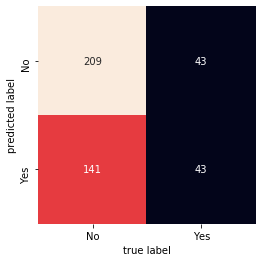

```python
X_train, X_test, y_train, y_test = train_test_split(dfallnondup, dfallnondup["top"], stratify=dfallnondup["top"],test_size=0.2)
features=['danceability','energy','key','loudness','mode' ,'speechiness','acousticness','instrumentalness','liveness','valence','tempo','time_signature']
# Divide by class
df0 = X_train[X_train['top'] == 0]
df1 = X_train[X_train['top'] == 1]
df1count=df1.shape[0]
df0count=df0.shape[0]
print('df1count ',df1count)
print('df0count ',df0count)
df1_over = df1.sample(df0count, replace=True)
print('df1_over ', df1_over.shape[0])
X_trainb=pd.concat([df1_over, df0], ignore_index=True) #new training Xb balanced
y_train=X_trainb['top']
X_trainb=X_trainb[features]
X_test=X_test[features]
#retry logistic
logReg = LogisticRegression(max_iter=10000)
logReg.fit(X_trainb, y_train)
y_pred=predictions = logReg.predict(X_test)

print("Accuracy Score:",accuracy_score(y_test,y_pred))
print("Recall Score:",recall_score(y_test,y_pred,labels=[1,0]))
print("Precision Score:",precision_score(y_test,y_pred,labels=[1,0]))
print("F1 Score:",f1_score(y_test,y_pred,labels=[1,0]))

mat = confusion_matrix(y_test, y_pred)
s1=sns.heatmap(mat.T, square=True, annot=True, fmt='d', cbar=False,
          xticklabels=['No','Yes'],
          yticklabels=['No','Yes'] )
plt.xlabel('true label')
plt.ylabel('predicted label')
bottom, top = s1.get_ylim()
s1.set_ylim(bottom + 0.5, top - 0.5)
```

```
df1count  344
df0count  1397
df1_over  1397
Accuracy Score: 0.5298165137614679
Recall Score: 0.45348837209302323
Precision Score: 0.19796954314720813
F1 Score: 0.2756183745583039
```

```
(2.0, 0.0)
```

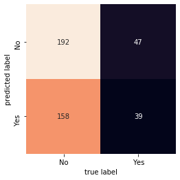

```python
# Add a cross validation for logistic regression
X_train, X_test, y_train, y_test = train_test_split(dfallnondup, dfallnondup["top"], stratify=dfallnondup["top"],test_size=0.2)
features=['danceability','energy','key','loudness','mode' ,'speechiness','acousticness','instrumentalness','liveness','valence','tempo','time_signature']
# Divide by class
df0 = X_train[X_train['top'] == 0]
df1 = X_train[X_train['top'] == 1]
df1count=df1.shape[0]
df0count=df0.shape[0]
print('df1count ',df1count)
print('df0count ',df0count)
df1_over = df1.sample(df0count, replace=True)
print('df1_over ', df1_over.shape[0])
X_trainb=pd.concat([df1_over, df0], ignore_index=True) #new training Xb balanced
y_train=X_trainb['top']
X_trainb=X_trainb[features]
X_test=X_test[features]
#retry logistic

logReg = LogisticRegressionCV(Cs=np.logspace(-1, 6, 8), cv=5, scoring="f1",max_iter=10000)
logReg.fit(X_trainb, y_train)
y_pred=predictions = logReg.predict(X_test)

print("Accuracy Score:",accuracy_score(y_test,y_pred))
print("Recall Score:",recall_score(y_test,y_pred,labels=[1,0]))
print("Precision Score:",precision_score(y_test,y_pred,labels=[1,0]))
print("F1 Score:",f1_score(y_test,y_pred,labels=[1,0]))

mat = confusion_matrix(y_test, y_pred)
s1=sns.heatmap(mat.T, square=True, annot=True, fmt='d', cbar=False,
          xticklabels=['No','Yes'],
          yticklabels=['No','Yes'] )
plt.xlabel('true label')
plt.ylabel('predicted label')
bottom, top = s1.get_ylim()
s1.set_ylim(bottom + 0.5, top - 0.5)
```

## Regression Model

```python
from sklearn.model_selection import train_test_split
from sklearn.linear_model import LinearRegression, RidgeCV
from sklearn import svm
from sklearn.ensemble import RandomForestClassifier
from sklearn.metrics import confusion_matrix , classification_report, mean_squared_error, r2_score
from sklearn.metrics import roc_curve, precision_recall_curve, auc, make_scorer, recall_score, accuracy_score, precision_score, confusion_matrix,average_precision_score
```

### Feature Engineering for Regression

Besides keeping all the music quality features we used in out classifier model, we try to understand which kinds of time-series data could be introduced to our regressor.

Normally, the Spotify users may try to listen the songs which has already been popular. Therefore, we introduce the new features recording the stream in the last 5 appearances in the list and the position in the last list.

However, if the popular song stays too long on the top lists, the user may consider it “out-of-fashion” and streams less. In order to take this case into consideration, we introduced two other features:

Week-count: count how many times the song has been in the top 200 list Week-prev: when was the last time the song appeared in the top 200 list.  
Week: current week of the estimation, working together with the week-prev, we could observe if the song has felt out of the list in the past period.

### Step 1 Feature Selection & Dynamic Features

```python
dfall_fe = dfall.copy()
dfall_fe = dfall_fe.drop(columns = ['URL', 'uri','track_href','analysis_url','type','Track Name'])
dfall_fe_id_values = dfall_fe.id.unique().tolist()
cdff = ['counts','index_prev','week_prev','pos_prev','stream_prev']
vdff = np.empty((len(dfall_fe_id_values),len(cdff)))
vdff[:] = np.nan
dfFeature = pd.DataFrame(vdff,
                         index =dfall_fe_id_values, columns = cdff)
dfall_fe['hist'] = [0]*len(dfall_fe.index)
dfall_fe['new'] = [0]*len(dfall_fe.index)
```

```python
for i in range(dfall_fe.shape[0]):
    if np.isnan(dfFeature.at[dfall_fe.id[i],'counts']):
        dfall_fe.at[i,'new'] = 1
        dfall_fe.at[i,'hist'] = 1
        dfFeature.at[dfall_fe.id[i],'counts'] = 1
        dfFeature.at[dfall_fe.id[i],'stream_prev'] = dfall_fe.at[i,'Streams']
        dfFeature.at[dfall_fe.id[i],'stream_log1'] = dfall_fe.at[i,'Streams']
        dfFeature.at[dfall_fe.id[i],'stream_log2'] = dfall_fe.at[i,'Streams']
        dfFeature.at[dfall_fe.id[i],'stream_log3'] = dfall_fe.at[i,'Streams']
        dfFeature.at[dfall_fe.id[i],'stream_log4'] = dfall_fe.at[i,'Streams']
        dfall_fe.at[i,'week_prev'] = 0
        dfall_fe.at[i,'stream_prev'] = 0
        dfall_fe.at[i,'pos_prev'] = 200

    else:
        dfFeature.at[dfall_fe.id[i],'counts'] += 1
        dfall_fe.at[i,'week_prev'] = dfFeature.at[dfall_fe.id[i],'week_prev']
        dfall_fe.at[i,'stream_prev'] = dfFeature.at[dfall_fe.id[i],'stream_prev']
        dfall_fe.at[i,'stream_prev'] = dfFeature.at[dfall_fe.id[i],'stream_prev']
        dfall_fe.at[i,'pos_prev'] = dfFeature.at[dfall_fe.id[i],'pos_prev']
        dfall_fe.at[i,'hist'] = dfFeature.at[dfall_fe.id[i],'counts']
    dfFeature.at[dfall_fe.id[i],'index_prev'] = i
    dfFeature.at[dfall_fe.id[i],'week_prev'] = dfall_fe.at[i,'week']
    dfFeature.at[dfall_fe.id[i],'stream_log4'] = dfFeature.at[dfall_fe.id[i],'stream_log3']
    dfFeature.at[dfall_fe.id[i],'stream_log3'] = dfFeature.at[dfall_fe.id[i],'stream_log2']
    dfFeature.at[dfall_fe.id[i],'stream_log2'] = dfFeature.at[dfall_fe.id[i],'stream_log1']
    dfFeature.at[dfall_fe.id[i],'stream_log1'] = dfFeature.at[dfall_fe.id[i],'stream_prev']
    dfFeature.at[dfall_fe.id[i],'stream_prev'] = dfall_fe.at[i,'Streams']
    dfFeature.at[dfall_fe.id[i],'pos_prev'] = dfall_fe.at[i,'Position']
    dfall_fe.at[i,'stream_avg'] = 1/5*(dfall_fe.at[i,'Streams'] + dfFeature.at[dfall_fe.id[i],'stream_prev']
                                      + dfFeature.at[dfall_fe.id[i],'stream_log1']+ dfFeature.at[dfall_fe.id[i],'stream_log2']
                                      + dfFeature.at[dfall_fe.id[i],'stream_log3']+ dfFeature.at[dfall_fe.id[i],'stream_log4'])
```

### Step 2 Feature Augmentation

```python
features=['danceability','energy','key','loudness','mode' ,'speechiness','acousticness','instrumentalness','liveness','valence','tempo','new','week','week_prev','pos_prev','stream_prev','duration_ms']
X_orig = dfall_fe[features]
from sklearn.preprocessing import StandardScaler
x = X_orig.values #returns a numpy array
std_scaler = StandardScaler()
x_scaled = std_scaler.fit_transform(x)

X_scaled = pd.DataFrame(x_scaled, columns = features)
```

```python
def generate_polynormial_features_set(X_scaled, k ):
    x_scaled = X_scaled.to_numpy()
    features = X_scaled.columns.tolist()
    for order in range(2,k+1):
        features_tmp = features
        for i in range(len(features)):
            features_tmp[i]= features[i]+'_'+str(order)
            x_tmp = x_scaled**order
        X_tmp = pd.DataFrame(x_tmp, columns = features_tmp)
        if order == 2:
            X_poly = X_tmp
        else:
            X_poly = pd.concat([X_poly, X_tmp], axis=1).reindex(X_poly.index)
    return X_poly
```

### Position Prediction – Use Regression to Classify the Top Songs

One of the limitations in our classification model is that the unbalanced dataset will generate the estimation bias. Although we could use some sampling approaches to generate a balanced dataset, new bias could be introduced during the process.

As the classification object “Top” is based on the value “Position”, one of the possible solutions is to change the classification problem to a regression problem on “Position”. The classification will be done based on the predicted “Position” value.

Different from the approach in our classification model, as the position is a time-dependent value, the model will be week-based. Some dynamic features will be introduced to improve the accuracy of the time series approach.

#### Linear Regression

```python
X = X_scaled
y = dfall['Position']
X_train, X_test, y_train, y_test = train_test_split(X, y, test_size=0.2)

regr = RidgeCV(alphas=[1e-3, 1e-2, 1e-1, 1])

# Train the model using the training sets
regr.fit(X_train, y_train)

# Make predictions using the testing set
y_pred = regr.predict(X_test)
y_pred_train = regr.predict(X_train)

# The coefficients
print('Coefficients: \n', regr.coef_)
# The mean squared error
print('Test Mean squared error: %.2f'
      % mean_squared_error(y_test, y_pred))
print('Train Mean squared error: %.2f'
      % mean_squared_error(y_train, y_pred_train))
# The coefficient of determination: 1 is perfect prediction
print('Coefficient of determination: %.2f'
      % r2_score(y_test, y_pred))
```

```
Coefficients:
 [-8.31976061e-01  1.29939630e+00 -3.48653726e-02 -3.61985815e-01
  5.07984686e-01  6.79383353e-01  9.65327872e-03  8.14731010e-02
  3.30657198e-01  1.80915550e-01 -4.30807225e-01 -3.63837200e+01
  2.78398036e+00 -3.58691199e+00  5.47397345e+01 -4.51834845e+00
  7.63684177e-01]
Test Mean squared error: 960.68
Train Mean squared error: 952.42
Coefficient of determination: 0.71
```

#### Polynomial Regression

```python
X_poly = generate_polynormial_features_set(X_scaled, 4)
X = pd.concat([X_scaled, X_poly], axis=1).reindex(X_scaled.index)
y = dfall['Position']
X_train, X_test, y_train, y_test = train_test_split(X, y, test_size=0.2)

regr = RidgeCV(alphas=[1e-3, 1e-2, 1e-1, 1])

# Train the model using the training sets
regr.fit(X_train, y_train)

# Make predictions using the testing set
y_pred = regr.predict(X_test)
y_pred_train = regr.predict(X_train)

# The coefficients
print('Coefficients: \n', regr.coef_)
# The mean squared error
print('Test Mean squared error: %.2f'
      % mean_squared_error(y_test, y_pred))
print('Train Mean squared error: %.2f'
      % mean_squared_error(y_train, y_pred_train))
# The coefficient of determination: 1 is perfect prediction
print('Coefficient of determination: %.2f'
      % r2_score(y_test, y_pred))
```

```
Coefficients:
 [-1.01514622e+00  1.65032246e+00 -1.44863250e-01 -2.53618145e-01
  2.79828299e-02  1.26468936e-01  7.60372030e-02  3.60417857e+00
  1.49993782e+00  1.81662106e+00 -3.13415255e-01 -1.27861510e-01
 -2.71528701e-01  4.15046692e-01  4.82873066e+01 -3.15215939e+01
  1.26488466e+00 -1.69067785e-01  5.53325713e-01  4.96816070e+00
  8.50340422e-02 -1.10584859e-02  3.20104262e-01  1.10526637e+00
 -1.75327969e+00 -4.43546765e-01  1.05386482e+00  8.81791671e-01
 -2.89877700e-01  3.88028751e+00 -2.42885576e+00  6.66150047e+00
  1.29377927e+01  3.13704459e-01  2.72759139e-01 -9.30510531e-02
  1.30348174e-01 -1.42088553e-02  3.23530138e-02 -3.93718894e-02
 -1.80780152e-01  1.97846693e-01 -1.15856878e-01 -7.01631765e-01
  2.43127551e-04 -7.85049751e-01  1.59508036e+00 -6.49100674e-01
 -4.94869716e+00 -1.96945183e+00 -1.31415389e-01  1.53274558e-01
 -1.04099723e-01 -1.85272879e+00 -5.12640411e-03 -2.38440172e-02
  3.70169966e-03 -5.15304258e-02 -6.14341814e-03  3.41926259e-02
 -1.12050811e-01 -1.84932129e-01 -2.06968161e+00 -1.88771572e-01
 -9.10932691e-01 -4.52319880e+00  9.50836559e-02  1.05762358e-02]
Test Mean squared error: 1000.20
Train Mean squared error: 914.97
Coefficient of determination: 0.70
```

#### Full features regression

```python
features_sqrt = features
for i in range(len(features)):
    features_sqrt[i]= features[i]+'_sqrt'

x_sqrt = np.sqrt(np.abs(x_scaled))
X_sqrt = pd.DataFrame(x_sqrt, columns = features_sqrt)

features_sin = features
for i in range(len(features)):
    features_sin[i]= features[i]+'_sin'

x_sin = np.sin(x_scaled)
X_sin = pd.DataFrame(x_sin, columns = features_sin)

features_cos = features
for i in range(len(features)):
    features_cos[i]= features[i]+'_cos'

x_cos = np.cos(x_scaled)
X_cos = pd.DataFrame(x_cos, columns = features_cos)
```

```python
X = pd.concat([X_scaled, X_poly, X_sqrt, X_sin, X_cos], axis=1).reindex(X_scaled.index)
y = dfall['Position']
X_train, X_test, y_train, y_test = train_test_split(X, y, test_size=0.2)

regr = RidgeCV(alphas=[1e-3, 1e-2, 1e-1, 1])

# Train the model using the training sets
regr.fit(X_train, y_train)

# Make predictions using the testing set
y_pred = regr.predict(X_test)
y_pred_train = regr.predict(X_train)

# The coefficients
print('Coefficients: \n', regr.coef_)
# The mean squared error
print('Test Mean squared error: %.2f'
      % mean_squared_error(y_test, y_pred))
print('Train Mean squared error: %.2f'
      % mean_squared_error(y_train, y_pred_train))
# The coefficient of determination: 1 is perfect prediction
print('Coefficient of determination: %.2f'
      % r2_score(y_test, y_pred))
```

```
Coefficients:
 [-3.19461710e+01 -2.93555094e+01  1.11231579e+02  1.66248585e+00
  6.03501142e-02 -2.19102782e+01  1.89576386e+02  1.75853932e+00
  1.47059301e+01 -6.81070398e+00  7.24213365e+00 -1.71243303e-01
  5.46563446e+02 -3.83874681e+02 -8.38648214e+00 -6.74415698e+01
  1.03104779e+00 -2.49586042e+01 -7.52442240e+00 -1.39379546e+00
 -8.72764186e-01 -2.38496570e-02  4.13702220e+00 -3.58233499e+01
 -1.50244609e+00  6.54582435e+00  3.80736410e+01 -2.63893295e+01
 -3.88229576e-01  1.05234343e+03 -9.72730693e+02  2.38625500e+02
  2.80435291e+01  6.03446318e-01  4.40636645e+00  4.18461694e+00
 -1.62776951e+01 -4.22175974e-01  6.97752282e-02  2.35986885e+00
 -3.19776151e+01  1.43260732e-01 -3.99876505e+00  4.47721036e-01
 -1.06028480e+00 -1.05140727e+00 -7.52567162e+01  5.47661118e+01
  5.02391201e+00 -3.95803352e+00 -2.00619087e-01  1.90407664e+00
  8.24163833e-01 -6.25001497e-01 -3.84320319e-02 -5.14240068e-02
 -3.72819543e-01  6.32691424e+00 -3.52215767e-03  4.21898961e-01
 -2.44746394e+00  1.48103660e+00 -2.77189850e+00 -7.63912482e+01
  6.86571669e+01 -2.35986745e+01  1.75705612e-01  1.36916637e-02
  6.27899190e-02  3.35844317e+00 -1.57015381e+00  4.36987982e-01
 -5.82124804e-03 -5.18694241e+00  1.76863724e+00  7.19296476e+00
 -2.19483454e+00  5.09119765e+00 -3.13663053e+00 -5.72965113e-02
  5.73495708e-01  6.80077015e+00 -1.59744188e+00  7.56203844e+00
  1.10682367e+00  3.22441389e+01  3.11365063e+01 -1.12490324e+02
 -8.39875336e-01  4.94475071e-02  2.29513645e+01 -1.88712579e+02
 -1.80924054e+00 -1.27456943e+01  8.62414367e+00 -7.46108273e+00
 -4.78851801e-02 -5.58958244e+02  3.91676404e+02  4.41048265e+01
  1.72712581e+01  1.39520111e-02 -5.09027915e+01 -1.20880926e+01
 -1.04099978e+01 -2.25987024e+00  9.89971410e-03  6.09372364e-01
 -6.37161743e+01  2.38677816e+00  1.18719982e+01  8.18732048e+01
 -6.04773920e+01  1.02448525e-01  2.12163826e+03 -1.95997864e+03
  4.62858988e+02 -9.05509811e+00  1.85329889e+00]
Test Mean squared error: 928.90
Train Mean squared error: 923.74
Coefficient of determination: 0.73
```

#### Regression to Full features

```
Accuracy Score: 0.9165865384615385
Recall Score: 0.6748826291079812
Precision Score: 0.8914728682170543
F1 Score: 0.7682030728122912
```

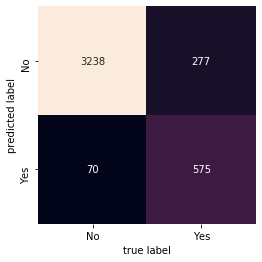

```python
y_test_clf = pd.DataFrame(y_test)
y_test_clf['top'] = np.where(y_test_clf['Position']<dfall.Position.quantile(0.2), 1, 0)
y_pred_clf = pd.DataFrame(data = y_pred, columns = ['Position'])
y_pred_clf['top'] = np.where(y_pred_clf['Position']<dfall.Position.quantile(0.2), 1, 0)

mat = confusion_matrix(y_test_clf['top'], y_pred_clf['top'])
s1=sns.heatmap(mat.T, square=True, annot=True, fmt='d', cbar=False,
          xticklabels=['No','Yes'],
          yticklabels=['No','Yes'] )
plt.xlabel('true label')
plt.ylabel('predicted label')
bottom, top = s1.get_ylim()
s1.set_ylim(bottom + 0.5, top - 0.5)

print("Accuracy Score:",accuracy_score(y_test_clf['top'],y_pred_clf['top']))
print("Recall Score:",recall_score(y_test_clf['top'],y_pred_clf['top'],labels=[1,0]))
print("Precision Score:",precision_score(y_test_clf['top'],y_pred_clf['top'],labels=[1,0]))
print("F1 Score:",f1_score(y_test_clf['top'],y_pred_clf['top'],labels=[1,0]))
```

## Regression based on Streams

Based on the current business model of Spotify, streaming number is the decisive factor for the singer's profit. We could therefore predict the future number of streams as the estimative indicator for the singer's profit from spotify.

The problem could be defined as a regression problem with continious output variable rather than binary-classfication. Therefore, We need to choose different models with different feature set for this problem. The coefficient of determination is chosen as the measure on the performance of our regressor.

### Linear Regression

```python
X = X_scaled
y = dfall['Streams']
X_train, X_test, y_train, y_test = train_test_split(X, y, test_size=0.2)

regr = RidgeCV(alphas=[1e-3, 1e-2, 1e-1, 1])

# Train the model using the training sets
regr.fit(X_train, y_train)

# Make predictions using the testing set
y_pred = regr.predict(X_test)
y_pred_train = regr.predict(X_train)

# The coefficients
print('Coefficients: \n', regr.coef_)
# The mean squared error
print('Test Mean squared error: %.2f'
      % mean_squared_error(y_test, y_pred))
print('Train Mean squared error: %.2f'
      % mean_squared_error(y_train, y_pred_train))
# The coefficient of determination: 1 is perfect prediction
print('Coefficient of determination: %.2f'
      % r2_score(y_test, y_pred))
```

```
Coefficients:
 [  43502.91787893  -67376.09640741   -6674.09074671   26153.05305781
  -12572.43231046  -26579.87336072   -9858.17133172  -18305.41566963
    3581.93353868  -10538.02908081   -3389.14488199 1081129.15962948
  -16803.51979857   38807.03246397 -111490.67778679 1726217.93028253
  -24790.83526795]
Test Mean squared error: 1795470051154.21
Train Mean squared error: 1596248222666.40
Coefficient of determination: 0.60
```

### Polynormial Regression

```python
X_poly = generate_polynormial_features_set(X_scaled, 4)
X = pd.concat([X_scaled, X_poly], axis=1).reindex(X_scaled.index)
y = dfall['Streams']
X_train, X_test, y_train, y_test = train_test_split(X, y, test_size=0.2)

regr = RidgeCV(alphas=[1e-3, 1e-2, 1e-1, 1])

# Train the model using the training sets
regr.fit(X_train, y_train)

# Make predictions using the testing set
y_pred = regr.predict(X_test)
y_pred_train = regr.predict(X_train)

# The coefficients
print('Coefficients: \n', regr.coef_)
# The mean squared error
print('Test Mean squared error: %.2f'
      % mean_squared_error(y_test, y_pred))
print('Train Mean squared error: %.2f'
      % mean_squared_error(y_train, y_pred_train))
# The coefficient of determination: 1 is perfect prediction
print('Coefficient of determination: %.2f'
      % r2_score(y_test, y_pred))
```

```
Coefficients:
 [ 4.10753839e+04 -6.30769149e+04  5.82051044e+04  3.08442094e+04
 -5.12052917e+01  1.26388258e+03  2.61170734e+03 -5.48894347e+04
 -2.71308513e+04 -5.30836167e+04  1.22301969e+04  2.32474927e+03
 -4.42115160e+05  4.29603382e+05 -5.92833942e+04  1.48805493e+06
 -9.02322517e+03  1.90966049e+03 -1.88283734e+04 -1.41447115e+05
  1.19323901e+04  2.02356415e+01 -2.19221199e+04 -8.26820639e+03
  3.25904578e+04  5.42050737e+04 -5.41133245e+04 -2.03816194e+04
  5.27049023e+03 -4.28215553e+04  1.85132704e+05 -2.85137630e+05
 -1.29410928e+05 -9.19811194e+03 -4.02249609e+03 -1.77222620e+03
 -4.28683413e+04 -5.31262573e+02 -5.92022400e+01  5.37584589e+03
 -5.27259680e+03 -4.01120508e+03 -2.03896679e+04  1.82893959e+04
 -1.32182489e+04  1.42735988e+04  1.82216790e+05 -3.11373798e+05
 -1.01776395e+05  2.34312393e+04 -5.00323608e+02 -2.13587250e+03
 -4.32855957e+02  4.54997014e+04 -2.56161133e+02  4.36316071e+01
 -7.16126953e+02  1.70675586e+03  1.30531250e+02  2.13609668e+03
  9.39387701e+03  9.20251172e+03  3.76304824e+04 -7.46305345e+04
  1.42996333e+05  2.50361389e+05 -1.05535938e+03  5.39541016e+01]
Test Mean squared error: 1563419833373.68
Train Mean squared error: 1604373401462.27
Coefficient of determination: 0.67
```

### Regression on Full features

```python
X = pd.concat([X_scaled, X_poly, X_sqrt, X_sin, X_cos], axis=1).reindex(X_scaled.index)
y = dfall['Streams']
X_train, X_test, y_train, y_test = train_test_split(X, y, test_size=0.2)

regr = RidgeCV(alphas=[1e-3, 1e-2, 1e-1, 1])

# Train the model using the training sets
regr.fit(X_train, y_train)

# Make predictions using the testing set
y_pred = regr.predict(X_test)
y_pred_train = regr.predict(X_train)

# The coefficients
print('Coefficients: \n', regr.coef_)
# The mean squared error
print('Test Mean squared error: %.2f'
      % mean_squared_error(y_test, y_pred))
print('Train Mean squared error: %.2f'
      % mean_squared_error(y_train, y_pred_train))
# The coefficient of determination: 1 is perfect prediction
print('Coefficient of determination: %.2f'
      % r2_score(y_test, y_pred))
```

```
Coefficients:
 [ 1.37532809e+06  5.85399937e+05 -5.98888964e+05  3.00564605e+05
 -1.78242934e+03  2.01755801e+05  2.11186567e+06  1.36224860e+05
 -3.37640112e+05  2.10692936e+05 -1.22340674e+06  4.25315889e+03
 -3.48456346e+07  4.08161992e+07  2.57950547e+07  2.85937143e+06
  3.28495931e+04  3.48329366e+05 -6.60722545e+04 -7.96196342e+06
 -2.80417323e+04  7.04395004e+02 -8.28481954e+04 -2.51801583e+06
  4.69834368e+04 -2.72945915e+05  1.71210606e+06  3.30872597e+06
  9.64243259e+03 -2.48385126e+07  2.23715189e+07 -4.84445260e+07
 -1.13011585e+06 -4.88271475e+03 -1.98054895e+05 -8.76120981e+04
  5.57156421e+04 -4.66987218e+04 -2.06079763e+03 -8.52518237e+03
 -2.46404789e+05 -6.60408984e+03  1.25102186e+05 -1.84878765e+04
  1.55649420e+05  2.61137332e+04  4.98856648e+06 -6.18744613e+06
 -3.88621113e+06  1.84662831e+05 -2.82288977e+03 -4.37843259e+04
 -6.01523682e+03  6.32090491e+05 -5.28980396e+03  1.51879824e+03
  2.19610742e+03  1.62177838e+05  2.24500000e+02 -1.18266836e+04
 -1.04629906e+05 -2.10723138e+05  6.88454504e+04  1.66633165e+06
 -1.19229659e+06  3.83646198e+06 -8.51406250e+03  1.59066162e+02
 -2.39284707e+05 -1.21798762e+05  1.86434272e+04 -8.41141349e+04
  1.71929471e+02 -3.24407831e+04  1.52349199e+05 -6.74875803e+05
  4.36552170e+04  1.56650586e+04  1.64873732e+05  1.42306997e+03
 -1.56993877e+05 -9.98075449e+04  1.40253082e+05  5.43182550e+05
 -3.27951273e+04 -1.38743576e+06 -7.06389645e+05  6.77410128e+05
 -2.57434633e+05 -1.46042262e+03 -2.16118396e+05 -2.19985543e+06
  4.26797324e+04  2.39698612e+05 -2.64236292e+05  1.26788309e+06
  1.18932122e+03  3.52069733e+07 -4.09762374e+07 -2.59683904e+07
 -9.54507584e+05 -7.07675828e+04  4.35682606e+05 -2.69099546e+05
 -1.57273894e+07 -2.11254524e+05 -2.92386215e+02 -7.50310859e+04
 -4.96173901e+06 -1.28841534e+05 -5.69034271e+05  3.67328123e+06
  7.02930938e+06 -2.54450683e+03 -5.07780530e+07  4.62121096e+07
 -9.69463216e+07 -1.43090858e+05 -3.49344647e+03]
Test Mean squared error: 1523490010450.09
Train Mean squared error: 1582837416223.16
Coefficient of determination: 0.63
```